# PMIT - Data Cleaning, Summary, and Visualizations

Charlie Whittaker

2/20/2026

```r
library(openxlsx)
library(tidyverse)
library(ggrepel)
library(ggpubr)
library(purrr)
library(knitr)
library(lubridate)
library(patchwork)
```

# Data Import

```r
ilabs <- read.xlsx("../data/stock_ilabs.xlsx")
ilabs.pmit <- ilabs %>% dplyr::filter(Core.Name %in% c("Preclinical Modeling (ES Cell and Transgenics Facility)","Animal Imaging and Preclinical Testing Core", "ES Cell and Transgenics Facility"))
rm(ilabs)
```

### Repair ilabs date

```r
ilabs.pmit$Purchase.Date <- as.Date(ilabs.pmit$Purchase.Date, origin = "1899-12-30")
```

### Check dates before range selection

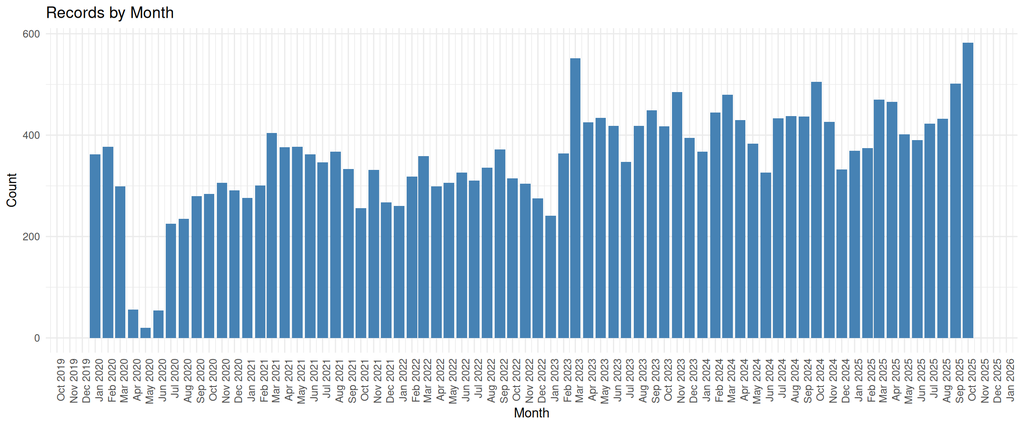

```r
ilabs.pmit %>%
  mutate(Year_Month = floor_date(Purchase.Date, "month")) %>%
  count(Year_Month) %>%
  arrange(Year_Month) %>%
  ggplot(aes(x = Year_Month, y = n)) +
  geom_col(fill = "steelblue") +
  scale_x_date(date_labels = "%b %Y", date_breaks = "1 month") +
  labs(title = "Records by Month",
       x = "Month",
       y = "Count") +
  theme_minimal() +
  theme(axis.text.x = element_text(angle = 90, hjust = 1))
```

### Select reporting date range

```r
cat("Dimensions of ilabs.pmit before reporting range selection:", dim(ilabs.pmit), "\n")
```

```
## Dimensions of ilabs.pmit before reporting range selection: 24922 19
```

```r
ilabs.pmit <- ilabs.pmit %>% dplyr::filter(between(Purchase.Date, as.Date("2020-05-01"), as.Date("2025-10-31")))
cat("Dimensions of ilabs.pmit after reporting range selection:", dim(ilabs.pmit), "\n")
```

```
## Dimensions of ilabs.pmit after reporting range selection: 23805 19
```

### Check dates after reporting range selection

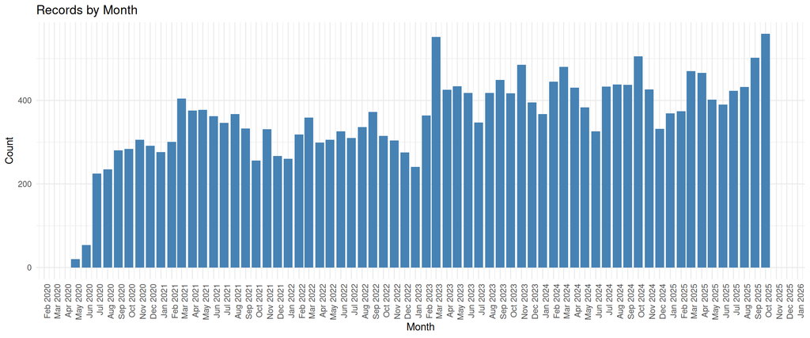

```r
ilabs.pmit %>%
  mutate(Year_Month = floor_date(Purchase.Date, "month")) %>%
  count(Year_Month) %>%
  arrange(Year_Month) %>%
  ggplot(aes(x = Year_Month, y = n)) +
  geom_col(fill = "steelblue") +
  scale_x_date(date_labels = "%b %Y", date_breaks = "1 month") +
  labs(title = "Records by Month",
       x = "Month",
       y = "Count") +
  theme_minimal() +
  theme(axis.text.x = element_text(angle = 90, hjust = 1))
```

# Faculty Annotation Work

### Import faculty key data

```r
fac.key <- read.xlsx("../data/FacultyKeys.xlsx")
```

### Associate Faculty.Key with ilabs.pmit

```r
ilabs.pmit <- ilabs.pmit %>%
  left_join(fac.key %>%
              select(ValueInData, Faculty.Key) %>%
              distinct(),
            by = c("Customer.Lab" = "ValueInData"))
```

### Import sponsor annotation data

```r
fac.annot <- read.xlsx("../data/annotated.Faculty.Keys.xlsx")
```

### Join sponsorship to ilabs.pmit using Faculty.Key

```r
ilabs.pmit <- ilabs.pmit %>%
  dplyr::left_join(
    fac.annot %>% dplyr::select(Faculty.Key, PMIT_Sponsor),
    by = "Faculty.Key"
  )
```

### Simplify sponsor associations for plotting

#### Import simplified categories

```r
sponsor.toPlot <- read.xlsx("../data/sponsor.Keys.ForPlotting.xlsx")
sponsor.toPlot
```

```
##           Sponsor Sponsor_ForPlot
## 1       KI_member   Center_Member
## 2    KI_affiliate   Center_Member
## 3     MIT_sponsor     MIT_Sponsor
## 4 MIT_non_sponsor     Non_Sponsor
## 5        external     Non_Sponsor
## 6        industry     Non_Sponsor
```

#### Join simplified sponsor data to ilabs.pmit

```r
ilabs.pmit <- ilabs.pmit %>%
  dplyr::left_join(sponsor.toPlot, by = c("PMIT_Sponsor" = "Sponsor"))
```

# Service Annotation

This may be necessary to facilitate data type selections for plotting

## Parse Charge.Name

```r
ilabs.pmit <- ilabs.pmit %>% dplyr::mutate(Charge.Name.Short = stringr::str_trim(stringr::str_extract(Charge.Name, "^[^|]*")))
```

### Check the results

```r
as.data.frame(table(ilabs.pmit$Charge.Name.Short)) %>% arrange(desc(Freq))
```

```
##                                                                                             Var1
## 1                                                                                IVIS 2 (IVIS 2)
## 2                                                                                IVIS 1 (IVIS 1)
## 3                                                Imaging Analysis Workstations (Sonic (Windows))
## 4                                                      Ultrasound and Photoacoustic (Ultrasound)
## 5                                               Imaging Analysis Workstations (Photon (Windows))
## 6                                                                             MicroCT (MicroCT1)
## 7                                                                                IVIS 3 (IVIS 3)
## 8                                                                          IVIS 1 and 3 (IVIS 1)
## 9                                                             Workstation Access- Monthly Charge
## 10                                                                   Mycoplasma Testing - all in
## 11                                                                                     MRI (MRI)
## 12                                                                        Isoflurane, per bottle
## 13                                                                         IVIS 1 and 3 (IVIS 3)
## 14                                                                                 Assisted Work
```

[output cut: 283 more lines]

# Data Visualizations

## Define Color Palette

```r
# Define colors for each Sponsor (adjust these hex codes as needed)
# Original palette
# sponsor_colors <- c(
#   "Center_Member" = "steelblue2",
#   "MIT_Sponsor" = "orange",
#   "Non_Sponsor" = "#C16644"
# )

# Colorblind safe 3
sponsor_colors <- c(
  "Center_Member" = "#56B4E9",
  "MIT_Sponsor" = "#E69F00",
  "Non_Sponsor" = "#009E73"
)

# Define order of sponsors for stacking (top to bottom)
sponsor_order <- c("Center_Member", "MIT_Sponsor", "Non_Sponsor")
```

### Instrument Use: Assisted or Training

1. Include usage.type that includes “Assisted”, “Consultation”, or “Training” (n=1854)
2. Exclude usage.type that includes “Assisted Data Analysis” (n=31)
3. Include usage.type = N/A and Category = “CFT Services” (n=58)
4. Include usage.type = N/A and Category = “PET consumables and time” and Unit.of.Measure = hours (n=291)
5. Include usage.type = N/A and Category = “PET consumables and time” and Unit.of.Measure = sample (n=34), count = sum of quantity/100

```r
train.1 <- ilabs.pmit %>% dplyr::filter(str_detect(Usage.Type, "Assisted|Consultation|Training")) %>% dplyr::filter(!Usage.Type == "Assisted Data Analysis")
cat("Rows train1:", dim(train.1)[1], "\n")
```

```
## Rows train1: 1823
```

```r
train.2 <- ilabs.pmit %>% dplyr::filter(Usage.Type == "N/A" & Category %in% c("CFT services"))
cat("Rows train2:", dim(train.2)[1], "\n")
```

```
## Rows train2: 58
```

```r
train.3 <- ilabs.pmit %>% dplyr::filter(Usage.Type == "N/A" & Category %in% c("PET consumables and time") & Unit.of.Measure == "hour")
cat("Rows train3:", dim(train.3)[1], "\n")
```

```
## Rows train3: 291
```

```r
train.4 <- ilabs.pmit %>% dplyr::filter(Usage.Type == "N/A" & Category %in% c("PET consumables and time") & Unit.of.Measure == "Sample")
# adjust the Quantity for train.4 (Samples) by dividing value by 100
train.4 <- train.4 %>%dplyr::mutate(Quantity = Quantity / 100)
cat("Rows train4:", dim(train.4)[1], "\n")
```

```
## Rows train4: 34
```

#### Combine the train objects

```r
train <- rbind(train.1,train.2,train.3,train.4)
```

### Prepare Instrument Use: Assisted or Training pie chart

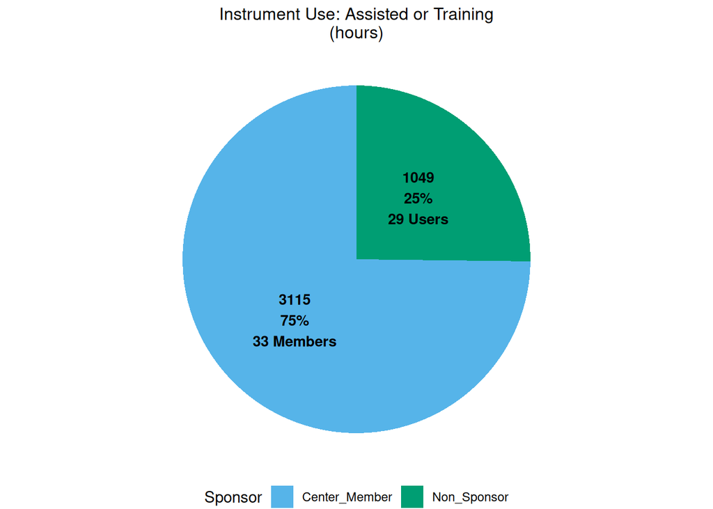

```r
train.pie <- train %>%
  mutate(Sponsor_ForPlot = factor(Sponsor_ForPlot, levels = sponsor_order)) %>%
  group_by(Sponsor_ForPlot) %>%
  summarise(Quantity = sum(round(Quantity,0)),
            Num_Labs = if_else(first(Sponsor_ForPlot) == "Center_Member",
                               n_distinct(Faculty.Key[PMIT_Sponsor == "KI_member"]),
                               n_distinct(Faculty.Key)),
            .groups = "drop") %>%
  mutate(Percent = round((Quantity / sum(Quantity)) * 100, 0),
         Lab_Label = if_else(Sponsor_ForPlot == "Center_Member",
                             paste0(Num_Labs, " Members"),
                             paste0(Num_Labs, " Users")),
         Label = paste0(Quantity, "\n", Percent, "%\n", Lab_Label)) %>%
  ggplot(aes(x = "", y = Quantity, fill = Sponsor_ForPlot)) +
  geom_col() +
  geom_text(aes(label = Label),
            position = position_stack(vjust = 0.5),
            size = 3.6,
            fontface = "bold",
            color = "black") +
  coord_polar("y", start = 0) +
  scale_fill_manual(values = sponsor_colors) +
  labs(title = "Instrument Use: Assisted or Training\n(hours)",
       fill = "Sponsor") +
  theme_void() +
  theme(legend.position = "bottom",
        plot.title = element_text(size = 12,
                                  face = "plain",
                                  hjust = 0.5))

train.pie
```

### Instrument Use: Trained

1. Include usage.type that includes “Independent”, or “Trained” (n=16844)
2. Include usage.type = N/A and Category = “Equipment Usage” (n=92)

```r
use.1 <- ilabs.pmit %>% dplyr::filter(str_detect(Usage.Type, "Independent|Trained")) %>% dplyr::filter(!Usage.Type == "Assisted Data Analysis")
cat("Rows use.1:", dim(use.1)[1], "\n")
```

```
## Rows use.1: 16844
```

```r
use.2 <- ilabs.pmit %>% dplyr::filter(Usage.Type == "N/A" & Category %in% c("Equipment Usage"))
cat("Rows use.2:", dim(use.2)[1], "\n")
```

```
## Rows use.2: 92
```

#### Combine the use objects

```r
use <- rbind(use.1,use.2)
```

### Prepare Instrument Use: Trained pie chart

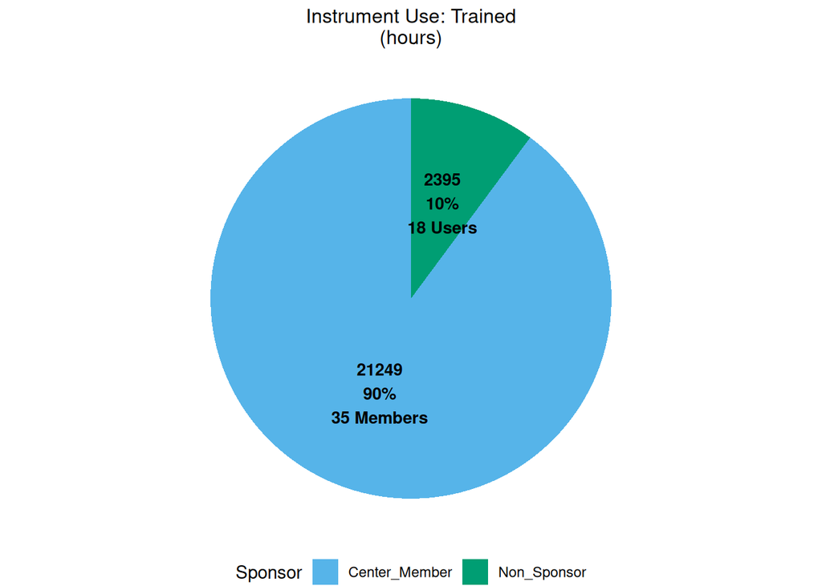

```r
use.pie <- use %>%
  mutate(Sponsor_ForPlot = factor(Sponsor_ForPlot, levels = sponsor_order)) %>%
  group_by(Sponsor_ForPlot) %>%
  summarise(Quantity = sum(round(Quantity,0)),
            Num_Labs = if_else(first(Sponsor_ForPlot) == "Center_Member",
                               n_distinct(Faculty.Key[PMIT_Sponsor == "KI_member"]),
                               n_distinct(Faculty.Key)),
            .groups = "drop") %>%
  mutate(Percent = round((Quantity / sum(Quantity)) * 100, 0),
         Lab_Label = if_else(Sponsor_ForPlot == "Center_Member",
                             paste0(Num_Labs, " Members"),
                             paste0(Num_Labs, " Users")),
         Label = paste0(Quantity, "\n", Percent, "%\n", Lab_Label)) %>%
  ggplot(aes(x = "", y = Quantity, fill = Sponsor_ForPlot)) +
  geom_col() +
  geom_text(aes(label = Label),
            position = position_stack(vjust = 0.5),
            size = 3.6,
            fontface = "bold",
            color = "black") +
  coord_polar("y", start = 0) +
  scale_fill_manual(values = sponsor_colors) +
  labs(title = "Instrument Use: Trained\n(hours)",
       fill = "Sponsor") +
  theme_void() +
  theme(legend.position = "bottom",
        plot.title = element_text(size = 12,
                                  face = "plain",
                                  hjust = 0.5))

use.pie
```

## Modeling Services

1. Include usage.type = N/A and Category = “Cell Testing Services” and Unit.of.Measure = Sample (n=585) - avg chg per unit = $40.60
2. Include usage.type = N/A and Category = “ES Cell Culture” and Unit.of.Measure = Each or Set (n=62) - avg chg per unit = $360.04
3. Include usage.type = N/A and Category = “Gene Targeting in ES Cells” (n=13) - avg chg per unit = $3062.79
4. Include usage.type = N/A and Category = “Microinjection” (n=38) - avg chg per unit = $341.92
5. Include usage.type = N/A and Category = “Request Cells” (n=315) - avg chg per unit = $137.96
6. Include usage.type = N/A and Category = (Blanks) (n=13) - avg chg per unit = $25
7. Include usage.type = N/A and Category = “Hourly Services” and Charge.Name = “Assisted Work” n=315) - avg chg per unit = $133.80
8. Include usage.type = N/A and Category = “Hourly Services” and Charge.Name contains “Monthly Charge” (n=30) - avg chg per unit = $927.40
9. Include usage.type = N/A and Category = “Hourly Services” and Charge.Name contains “Consultation” and Core.Name contains “ES Cell” or “Modeling” (n=34) - avg chg per unit = $203.23
10. Include usage.type = N/A and Category = “Hourly Services” and Charge.Name = “Training” and Core.Name contains “ES Cell” or “Modeling” (n=23) - avg chg per unit = $126.96

```r
model.serv.1 <- ilabs.pmit %>% dplyr::filter(Usage.Type == "N/A" &
                                                 Category == "Cell Testing Services" &
                                                 Unit.of.Measure == "Sample")
cat("Rows model.serv.1:", dim(model.serv.1)[1], "\n")
```

```
## Rows model.serv.1: 585
```

```r
# model.serv.1.priceMean <- mean(model.serv.1$Price, na.rm = TRUE)
# cat("Mean model.serv.1:", model.serv.1.priceMean, "\n")
# model.serv.1 <- model.serv.1 %>% dplyr::mutate(Quantity.Norm = round(Quantity * model.serv.1.priceMean,0))

model.serv.2 <- ilabs.pmit %>% dplyr::filter(Usage.Type == "N/A" &
                                                 Category == "ES Cell Culture" &
                                                 Unit.of.Measure %in% c("each","set"))
cat("Rows model.serv.2:", dim(model.serv.2)[1], "\n")
```

```
## Rows model.serv.2: 62
```

```r
# model.serv.2.priceMean <- mean(model.serv.2$Price, na.rm = TRUE)
# cat("Mean model.serv.3:", model.serv.2.priceMean, "\n")
# model.serv.2 <- model.serv.2 %>% dplyr::mutate(Quantity.Norm = round(Quantity * model.serv.2.priceMean,0))

model.serv.3 <- ilabs.pmit %>% dplyr::filter(Usage.Type == "N/A" &
                                                 Category == "Gene Targeting in ES cells")
cat("Rows model.serv.3:", dim(model.serv.3)[1], "\n")
```

```
## Rows model.serv.3: 13
```

```r
# model.serv.3.priceMean <- mean(model.serv.3$Price, na.rm = TRUE)
# cat("Mean model.serv.3:", model.serv.3.priceMean, "\n")
# model.serv.3 <- model.serv.3 %>% dplyr::mutate(Quantity.Norm = round(Quantity * model.serv.3.priceMean,0))

model.serv.4 <- ilabs.pmit %>% dplyr::filter(Usage.Type == "N/A" &
                                                 Category == "Microinjection")
cat("Rows model.serv.4:", dim(model.serv.4)[1], "\n")
```

```
## Rows model.serv.4: 38
```

```r
# model.serv.4.priceMean <- mean(model.serv.4$Price, na.rm = TRUE)
# cat("Mean model.serv.4:", model.serv.4.priceMean, "\n")
# model.serv.4 <- model.serv.4 %>% dplyr::mutate(Quantity.Norm = round(Quantity * model.serv.4.priceMean,0))

model.serv.5 <- ilabs.pmit %>% dplyr::filter(Usage.Type == "N/A" &
                                                 Category == "Request Cells")
cat("Rows model.serv.5:", dim(model.serv.5)[1], "\n")
```

```
## Rows model.serv.5: 315
```

```r
# model.serv.5.priceMean <- mean(model.serv.5$Price, na.rm = TRUE)
# cat("Mean model.serv.5:", model.serv.5.priceMean, "\n")
# model.serv.5 <- model.serv.5 %>% dplyr::mutate(Quantity.Norm = round(Quantity * model.serv.5.priceMean,0))

model.serv.6 <- ilabs.pmit %>% dplyr::filter(Usage.Type == "N/A" &
                                                 Category == "")
cat("Rows model.serv.6:", dim(model.serv.6)[1], "\n")
```

```
## Rows model.serv.6: 13
```

```r
# model.serv.6.priceMean <- mean(model.serv.6$Price, na.rm = TRUE)
# cat("Mean model.serv.6:", model.serv.6.priceMean, "\n")
# model.serv.6 <- model.serv.6 %>% dplyr::mutate(Quantity.Norm = round(Quantity * model.serv.6.priceMean,0))

model.serv.7 <- ilabs.pmit %>% dplyr::filter(Usage.Type == "N/A" &
                                               Category == "Hourly Services" &
                                               Charge.Name == "Assisted Work")
cat("Rows model.serv.7:", dim(model.serv.7)[1], "\n")
```

```
## Rows model.serv.7: 315
```

```r
# model.serv.7.priceMean <- mean(model.serv.7$Price, na.rm = TRUE)
# cat("Mean model.serv.7:", model.serv.7.priceMean, "\n")
# model.serv.7 <- model.serv.7 %>% dplyr::mutate(Quantity.Norm = round(Quantity * model.serv.7.priceMean,0))

model.serv.8 <- ilabs.pmit %>% dplyr::filter(Usage.Type == "N/A" &
                                               Category == "Hourly Services" &
                                               str_detect(Charge.Name,"Monthly Charge"))
cat("Rows model.serv.8:", dim(model.serv.8)[1], "\n")
```

```
## Rows model.serv.8: 30
```

```r
# model.serv.8.priceMean <- mean(model.serv.8$Price, na.rm = TRUE)
# cat("Mean model.serv.8:", model.serv.8.priceMean, "\n")
# model.serv.8 <- model.serv.8 %>% dplyr::mutate(Quantity.Norm = round(Quantity * model.serv.8.priceMean,0))

model.serv.9 <- ilabs.pmit %>% dplyr::filter(Usage.Type == "N/A" &
                                               Category == "Hourly Services" &
                                               str_detect(Charge.Name,"Consultation") &
                                               str_detect(Core.Name, "ES|Modeling"))
cat("Rows model.serv.9:", dim(model.serv.9)[1], "\n")
```

```
## Rows model.serv.9: 34
```

```r
# model.serv.9.priceMean <- mean(model.serv.9$Price, na.rm = TRUE)
# cat("Mean model.serv.9:", model.serv.9.priceMean, "\n")
# model.serv.9 <- model.serv.9 %>% dplyr::mutate(Quantity.Norm = round(Quantity * model.serv.9.priceMean,0))

model.serv.10 <- ilabs.pmit %>% dplyr::filter(Usage.Type == "N/A" &
                                                 Category == "Hourly Services" &
                                                Charge.Name == "Training" &
                                                str_detect(Core.Name, "ES|Modeling"))
cat("Rows model.serv.10:", dim(model.serv.10)[1], "\n")
```

```
## Rows model.serv.10: 23
```

```r
# model.serv.10.priceMean <- mean(model.serv.10$Price, na.rm = TRUE)
# cat("Mean model.serv.10:", model.serv.10.priceMean, "\n")
# model.serv.10 <- model.serv.10 %>% dplyr::mutate(Quantity.Norm = round(Quantity * model.serv.10.priceMean,0))
```

### Rate Modifiers

#### Function modify rates based on sponsorship categories

```r
modifyRates <- function(df, modifiers) {
  df %>%
    mutate(Price = Price * modifiers[PMIT_Sponsor])
}
```

### Apply the function to the model.serv dataframes

Note: Modifiers can be adjusted differently for the different selection groups

```r
# model.serv.1 <- modifyRates(model.serv.1, c(KI_member=1,KI_affiliate=1,MIT_non_sponsor=0.75,external=0.6,industry=0.5))
model.serv.1 <- model.serv.1 %>% dplyr::mutate(Quantity.Norm = round(Quantity * Price,0))

model.serv.2 <- modifyRates(model.serv.2, c(KI_member=1,KI_affiliate=1,MIT_non_sponsor=0.6,external=0.6,industry=0.3))
model.serv.2 <- model.serv.2 %>% dplyr::mutate(Quantity.Norm = round(Quantity * Price,0))

model.serv.3 <- modifyRates(model.serv.3, c(KI_member=1,KI_affiliate=1,MIT_non_sponsor=0.6,external=0.6,industry=0.3))
model.serv.3 <- model.serv.3 %>% dplyr::mutate(Quantity.Norm = round(Quantity * Price,0))

model.serv.4 <- modifyRates(model.serv.4, c(KI_member=1,KI_affiliate=1,MIT_non_sponsor=0.6,external=0.6,industry=0.3))
model.serv.4 <- model.serv.4 %>% dplyr::mutate(Quantity.Norm = round(Quantity * Price,0))

model.serv.5 <- modifyRates(model.serv.5, c(KI_member=1,KI_affiliate=1,MIT_non_sponsor=0.6,external=0.6,industry=0.3))
model.serv.5 <- model.serv.5 %>% dplyr::mutate(Quantity.Norm = round(Quantity * Price,0))

# model.serv.6 <- modifyRates(model.serv.6, c(KI_member=1,KI_affiliate=1,MIT_non_sponsor=0.75,external=0.6,industry=0.5))
model.serv.6 <- model.serv.6 %>% dplyr::mutate(Quantity.Norm = round(Quantity * Price,0))

model.serv.7 <- modifyRates(model.serv.7, c(KI_member=1,KI_affiliate=1,MIT_non_sponsor=0.75,external=0.6,industry=0.5))
model.serv.7 <- model.serv.7 %>% dplyr::mutate(Quantity.Norm = round(Quantity * Price,0))

# model.serv.8 <- modifyRates(model.serv.8, c(KI_member=1,KI_affiliate=1,MIT_non_sponsor=0.75,external=0.6,industry=0.5))
model.serv.8 <- model.serv.8 %>% dplyr::mutate(Quantity.Norm = round(Quantity * Price,0))

model.serv.9 <- modifyRates(model.serv.9, c(KI_member=1,KI_affiliate=1,MIT_non_sponsor=0.6,external=0.6,industry=0.3))
model.serv.9 <- model.serv.9 %>% dplyr::mutate(Quantity.Norm = round(Quantity * Price,0))

model.serv.10 <- modifyRates(model.serv.10, c(KI_member=1,KI_affiliate=1,MIT_non_sponsor=0.5,external=0.5,industry=0.5))
model.serv.10 <- model.serv.10 %>% dplyr::mutate(Quantity.Norm = round(Quantity * Price,0))
```

### Combine the model.serv objects

```r
model.serv <- rbind(model.serv.1,model.serv.2,model.serv.3,
                    model.serv.4,model.serv.5,model.serv.6,
                    model.serv.7,model.serv.8,model.serv.9,
                    model.serv.10)
```

### Prepare Modeling Services pie chart

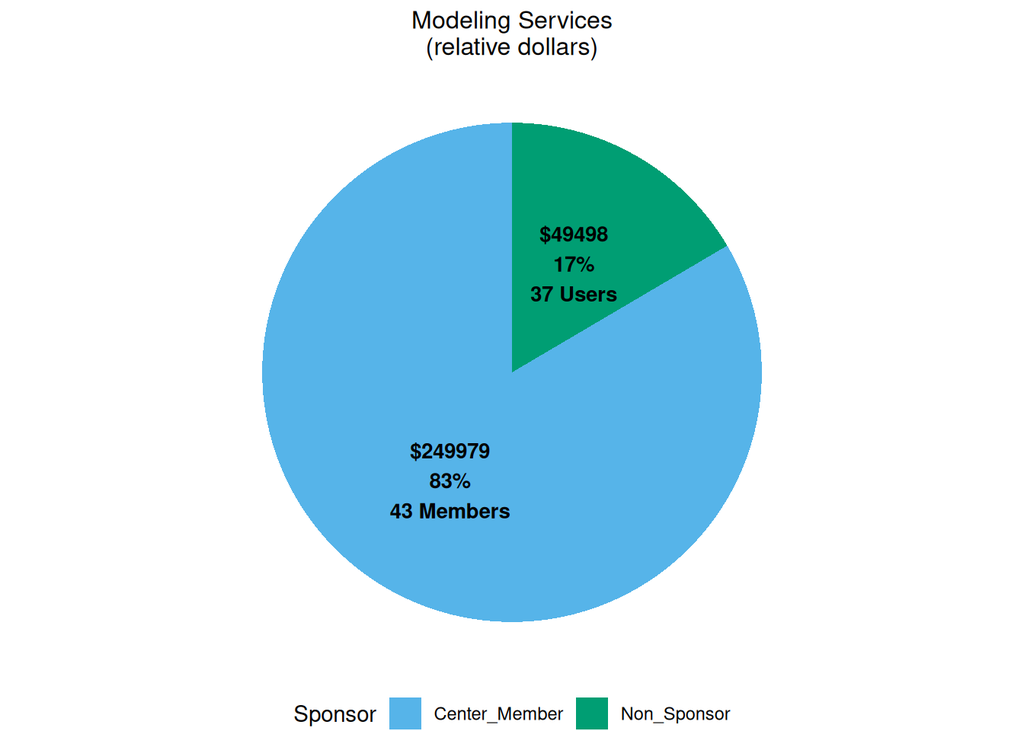

```r
model.serv.pie <- model.serv %>%
  mutate(Sponsor_ForPlot = factor(Sponsor_ForPlot, levels = sponsor_order)) %>%
  group_by(Sponsor_ForPlot) %>%
  summarise(Quantity = sum(round(Quantity.Norm,0)),
            Num_Labs = if_else(first(Sponsor_ForPlot) == "Center_Member",
                               n_distinct(Faculty.Key[PMIT_Sponsor == "KI_member"]),
                               n_distinct(Faculty.Key)),
            .groups = "drop") %>%
  mutate(Percent = round((Quantity / sum(Quantity)) * 100, 0),
         Lab_Label = if_else(Sponsor_ForPlot == "Center_Member",
                             paste0(Num_Labs, " Members"),
                             paste0(Num_Labs, " Users")),
         Label = paste0("$",Quantity, "\n", Percent, "%\n", Lab_Label)) %>%
  ggplot(aes(x = "", y = Quantity, fill = Sponsor_ForPlot)) +
  geom_col() +
  geom_text(aes(label = Label),
            position = position_stack(vjust = 0.5),
            size = 3.6,
            fontface = "bold",
            color = "black") +
  coord_polar("y", start = 0) +
  scale_fill_manual(values = sponsor_colors) +
  labs(title = "Modeling Services\n(relative dollars)",
       fill = "Sponsor") +
  theme_void() +
  theme(legend.position = "bottom",
        plot.title = element_text(size = 12,
                                  face = "plain",
                                  hjust = 0.5))

model.serv.pie
```

## Testing Services

1. Include usage.type = N/A and Category = “Animals and Husbandry” and Unit.of.Measure = hour (n=794)
2. Include usage.type = N/A and Category = “Hourly Services” and Charge.Name contains “Consultation” and Core.Name contains “Animal” (n=66)
3. Include usage.type = N/A and Category = “Hourly Services” and Charge.Name = “Training” and Core.Name contains “Animal” (n=23)

```r
testing.serv.1 <- ilabs.pmit %>% dplyr::filter(Usage.Type == "N/A" & Category == "Animals and Husbandry" & Unit.of.Measure == "hour")
cat("Rows testing.serv.1:", dim(testing.serv.1)[1], "\n")
```

```
## Rows testing.serv.1: 794
```

```r
testing.serv.2 <- ilabs.pmit %>% dplyr::filter(Usage.Type == "N/A" &
                                                 Category == "Hourly Services" &
                                                 str_detect(Charge.Name, "Consultation") &
                                                 str_detect(Core.Name, "Animal"))
cat("Rows testing.serv.2:", dim(testing.serv.2)[1], "\n")
```

```
## Rows testing.serv.2: 66
```

```r
testing.serv.3 <- ilabs.pmit %>% dplyr::filter(Usage.Type == "N/A" &
                                                 Category == "Hourly Services" &
                                                 str_detect(Charge.Name, "Training") &
                                                 str_detect(Core.Name, "Animal"))
cat("Rows testing.serv.3:", dim(testing.serv.3)[1], "\n")
```

```
## Rows testing.serv.3: 23
```

#### Combine the testing.serv objects

```r
testing.serv <- rbind(testing.serv.1,testing.serv.2,testing.serv.3)
```

### Prepare Testing Services pie chart

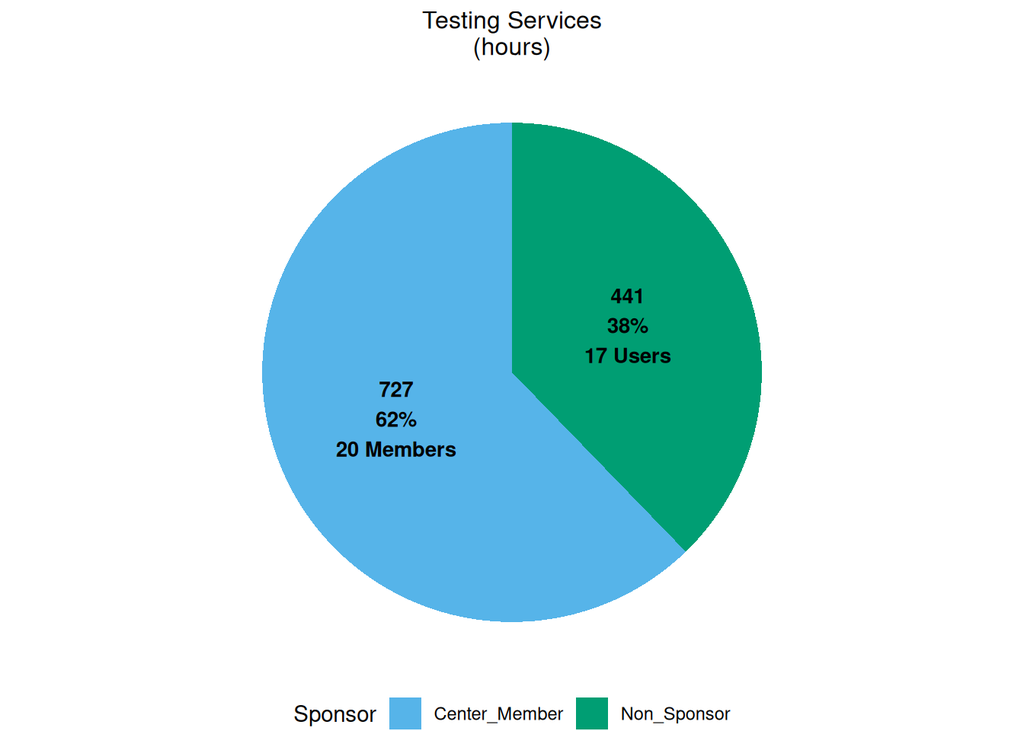

```r
testing.serv.pie <- testing.serv %>%
  mutate(Sponsor_ForPlot = factor(Sponsor_ForPlot, levels = sponsor_order)) %>%
  group_by(Sponsor_ForPlot) %>%
  summarise(Quantity = sum(round(Quantity,0)),
            Num_Labs = if_else(first(Sponsor_ForPlot) == "Center_Member",
                               n_distinct(Faculty.Key[PMIT_Sponsor == "KI_member"]),
                               n_distinct(Faculty.Key)),
            .groups = "drop") %>%
  mutate(Percent = round((Quantity / sum(Quantity)) * 100, 0),
         Lab_Label = if_else(Sponsor_ForPlot == "Center_Member",
                             paste0(Num_Labs, " Members"),
                             paste0(Num_Labs, " Users")),
         Label = paste0(Quantity, "\n", Percent, "%\n", Lab_Label)) %>%
  ggplot(aes(x = "", y = Quantity, fill = Sponsor_ForPlot)) +
  geom_col() +
  geom_text(aes(label = Label),
            position = position_stack(vjust = 0.5),
            size = 3.6,
            fontface = "bold",
            color = "black") +
  coord_polar("y", start = 0) +
  scale_fill_manual(values = sponsor_colors) +
  labs(title = "Testing Services\n(hours)",
       fill = "Sponsor") +
  theme_void() +
  theme(legend.position = "bottom",
        plot.title = element_text(size = 12,
                                  face = "plain",
                                  hjust = 0.5))

testing.serv.pie
```

## Data Analysis: Imaging and Testing

1. Include usage.type that includes “Analysis” (n=43)
2. Include usage.type = N/A and Category = “Hourly Services” and Charge.Name includes = “Analysis” (n=100)

```r
image.test.1 <- ilabs.pmit %>% dplyr::filter(str_detect(Usage.Type, "Analysis"))
cat("Rows image.test.1:", dim(image.test.1)[1], "\n")
```

```
## Rows image.test.1: 43
```

```r
image.test.2 <- ilabs.pmit %>% dplyr::filter(Usage.Type == "N/A" & Category == "Hourly Services" & str_detect(Charge.Name, "Analysis"))
cat("Rows image.test.2:", dim(image.test.2)[1], "\n")
```

```
## Rows image.test.2: 100
```

#### Combine the image.test objects

```r
image.test <- rbind(image.test.1,image.test.2)
as.hours <- image.test %>% dplyr::filter(str_detect(Notes, "AS"))
write.xlsx(as.hours, file="AS_hours_toDSMI.xlsx")
image.test <- image.test %>% dplyr::filter(!str_detect(Notes, "AS"))
```

### Prepare Data Analysis: Imaging and Testing pie chart

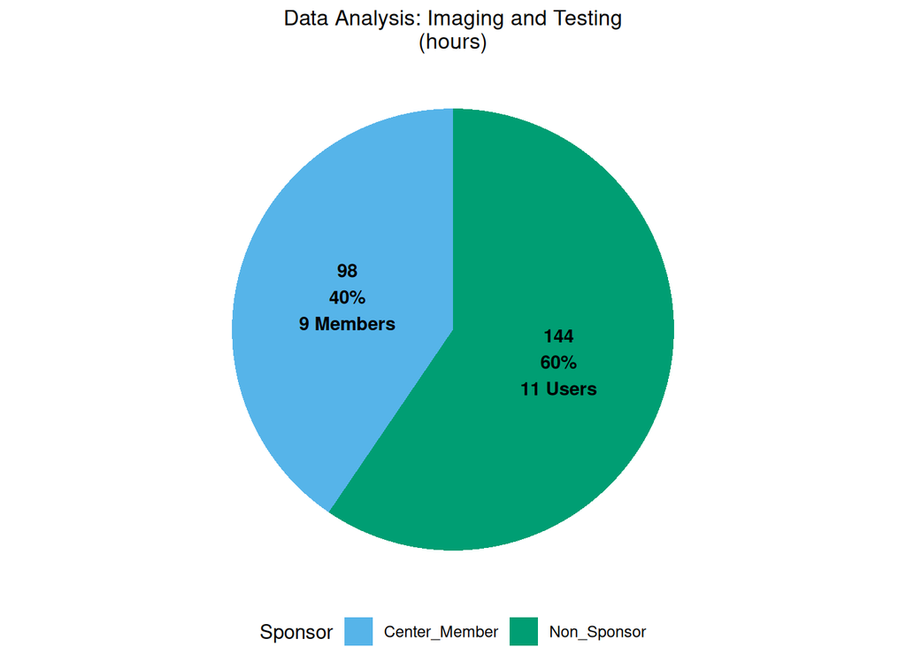

```r
image.test.pie <- image.test %>%
  mutate(Sponsor_ForPlot = factor(Sponsor_ForPlot, levels = sponsor_order)) %>%
  group_by(Sponsor_ForPlot) %>%
  summarise(Quantity = sum(round(Quantity,0)),
            Num_Labs = if_else(first(Sponsor_ForPlot) == "Center_Member",
                               n_distinct(Faculty.Key[PMIT_Sponsor == "KI_member"]),
                               n_distinct(Faculty.Key)),
            .groups = "drop") %>%
  mutate(Percent = round((Quantity / sum(Quantity)) * 100, 0),
         Lab_Label = if_else(Sponsor_ForPlot == "Center_Member",
                             paste0(Num_Labs, " Members"),
                             paste0(Num_Labs, " Users")),
         Label = paste0(Quantity, "\n", Percent, "%\n", Lab_Label)) %>%
  ggplot(aes(x = "", y = Quantity, fill = Sponsor_ForPlot)) +
  geom_col() +
  geom_text(aes(label = Label),
            position = position_stack(vjust = 0.5),
            size = 3.6,
            fontface = "bold",
            color = "black") +
  coord_polar("y", start = 0) +
  scale_fill_manual(values = sponsor_colors) +
  labs(title = "Data Analysis: Imaging and Testing\n(hours)",
       fill = "Sponsor") +
  theme_void() +
  theme(legend.position = "bottom",
        plot.title = element_text(size = 12,
                                  face = "plain",
                                  hjust = 0.5))

image.test.pie
```

# Plot the pie charts figure

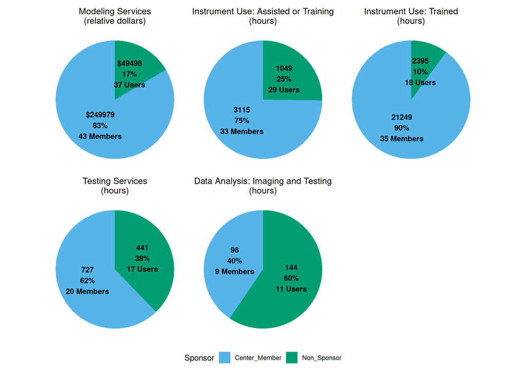

```r
model.serv.pie + train.pie + use.pie + testing.serv.pie + image.test.pie + plot_layout(ncol = 3, guides = "collect") &
  theme(legend.position = "bottom")
```

```r
combo.pie <- model.serv.pie + train.pie + use.pie + testing.serv.pie + image.test.pie + plot_layout(ncol = 3, guides = "collect") &
  theme(legend.position = "bottom")
ggsave("figures/PMIT_combo.pie.pdf",
       plot = combo.pie,
       dpi = 600,
       width = 10,
       height = 7,
       units = "in")
```

# Write annotated output file

```r
write.xlsx(ilabs.pmit,"pmit.final.xlsx")
```

```r
writeLines(capture.output(sessionInfo()), "PMIT_processing_sessionInfo.txt")
```